# Ejemplos de Estadística Inferencial con R

# COMPARACIÓN DE VARIOS GRUPOS INDEPENDIENTES

## Ejemplo 14.

En un experimento, se compara la expresión de un gen (en concentración de proteína) en tres mutantes (A, B, C). Los datos obtenidos en 9 cultivos son:

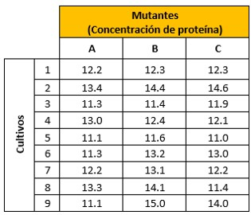

Ejemplo 14

| grupo | y |
| --- | --- |
| A | 12.2 |
| A | 13.4 |
| A | 11.3 |
| A | 13.0 |
| A | 11.1 |
| A | 11.3 |
| A | 12.2 |
| A | 13.3 |
| A | 11.1 |
| B | 12.3 |

[output cut: 17 more lines]

1. Seleccionar la prueba asociada.
1. Prueba paramétrica o no paramétrica.

Se evalúa la normalidad en de las tres muestras A, B y C:

```
##
##  Shapiro-Wilk normality test
##
## data:  A
## W = 0.85625, p-value = 0.08726
```

```
##
##  Shapiro-Wilk normality test
##
## data:  B
## W = 0.95297, p-value = 0.7226
```

```
##
##  Shapiro-Wilk normality test
##
## data:  C
## W = 0.92883, p-value = 0.4703
```

Las tres muestras cumplen las pruebas de normalidad.

Se calcula el ANOVA de un factor, así como la normalidad de sus residuales:

Se comprueba Normalidad de los residuales:

```
##
##  Shapiro-Wilk normality test
##
## data:  ANOVA$residuals
## W = 0.94867, p-value = 0.199
```

Se grafica Q-Q de los residuales de la ANOVA:

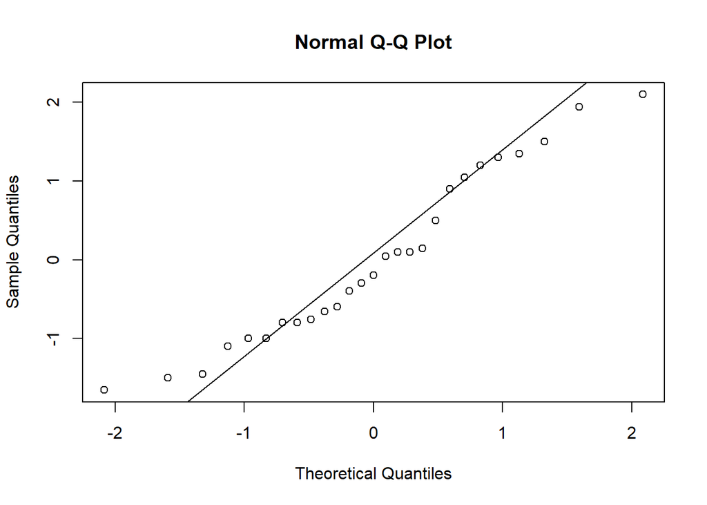

Se comprueba homocedasticidad con Bartlett:

```
##
##  Bartlett test of homogeneity of variances
##
## data:  y by grupo
## Bartlett's K-squared = 0.59755, df = 2, p-value = 0.7417
```

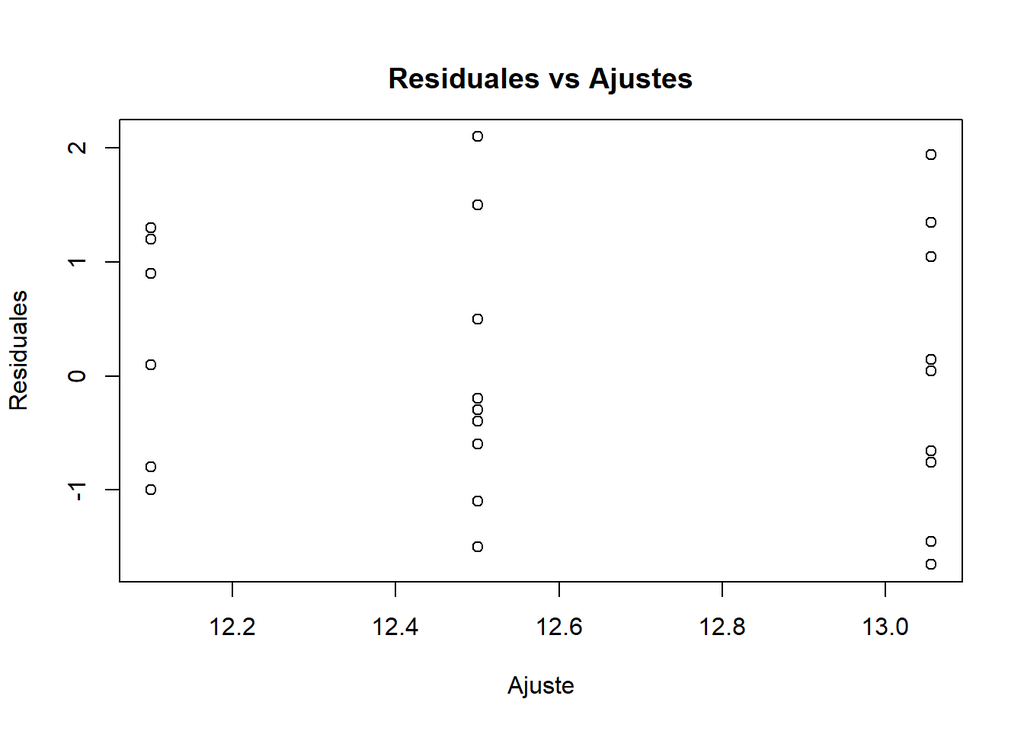

Hay normalidad en las variables; normalidad y homocedasticidad en los residuales del ANOVA.

Entonces será una prueba paramétrica.

2. Objetivo. Hacer una prueba de medias. Determinar si las concentraciones de proteína difieren o no en los 3 mutantes.
2. Establecer las hipótesis nula y alternativa.

$H_{0}$: las medias de los 3 grupos son idénticas $\mu_{A}$ = $\mu_{B}$ = $\mu_{C}$

$H_{1}$: al menos una de las medias es diferente.

3. Decidir un error aceptable.

   $\alpha$ = 0.05
4. Calcular la prueba estadística de los datos. (**ANOVA**)

Resumen del ANOVA:

```
## Call:
##    aov(formula = y ~ datos$grupo)
##
## Terms:
##                 datos$grupo Residuals
## Sum of Squares     4.145185 30.822222
## Deg. of Freedom           2        24
##
## Residual standard error: 1.133252
## Estimated effects may be unbalanced
```

```
##             Df Sum Sq Mean Sq F value Pr(>F)
## datos$grupo  2  4.145   2.073   1.614   0.22
## Residuals   24 30.822   1.284
```

5. Calcular el valor de *p*.

*p* = 0.2199916

6. Rechazar la hipótesis nula si *p* ≤ $\alpha$.

Como *p*(0.2199916) > $\alpha$(0.05) no hay evidencia para rechazar la $H_{0}$. $\mu_{A}$ = $\mu_{B}$ = $\mu_{C}$.

## Ejemplo 15.

Se implanta un experimento en el que los participantes recibían una entre tres posibles dosis de una droga experimental y tras la cual se medía el grado de vigilancia en una tarea. Analizar el comportamiento de la medias de los datos.

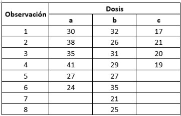

Ejemplo 15

Archivo de datos:

| Dosis | Vigilancia |
| --- | --- |
| a | 30 |
| a | 38 |
| a | 35 |
| a | 41 |
| a | 27 |
| a | 24 |
| b | 32 |
| b | 26 |
| b | 31 |
| b | 29 |

[output cut: 8 more lines]

1. Seleccionar la prueba apropiada
   1. Prueba paramétrica o no paramétrica. (Normalidad y Homocedasticidad)

**Normalidad de de los grupos a, b y c:**

```
##
##  Shapiro-Wilk normality test
##
## data:  a
## W = 0.96129, p-value = 0.8296
```

```
##
##  Lilliefors (Kolmogorov-Smirnov) normality test
##
## data:  a
## D = 0.14767, p-value = 0.9496
```

```
##
##  Shapiro-Wilk normality test
##
## data:  b
## W = 0.99106, p-value = 0.9965
```

```
##
##  Anderson-Darling normality test
##
## data:  b
## A = 0.12611, p-value = 0.9719
```

```
##
##  Lilliefors (Kolmogorov-Smirnov) normality test
##
## data:  b
## D = 0.11104, p-value = 0.9942
```

```
##
##  Shapiro-Wilk normality test
##
## data:  c
## W = 0.97137, p-value = 0.85
```

Cumplen con normalidad todas las dosis con sus respectivas vigilancias.

**Probando homocedasticidad: Homogeneidad de varianza**

La homocedasticidad permite contrastar la igualdad de varianza en 2 o más poblaciones y la prueba de Bartlett se recomienda para muestras que proceden de poblaciones normales (normalidad) y sin necesidad de que el tamaño de los grupos sea el mismo.

Por otro lado, si no se tiene la seguridad de que las poblaciones de origen son normales, se recomiendan el test de *Leven* utilizando la mediana o el test no paramétrico *Fligner-Killeen* que también se basa en la mediana. https://rpubs.com/Joaquin_AR/218466

```
##
##  Bartlett test of homogeneity of variances
##
## data:  Vigilancia by Dosis
## Bartlett's K-squared = 4.4546, df = 2, p-value = 0.1078
```

Hay homocedasticidad considerando que *p*(0.1078195) > $\alpha$(0.05)

Para complementar este análisis de los grupos, se generan diagramas de caja con los datos de cada grupo, así como se hacen cáclulos de la media y desviación estándar de cada grupo

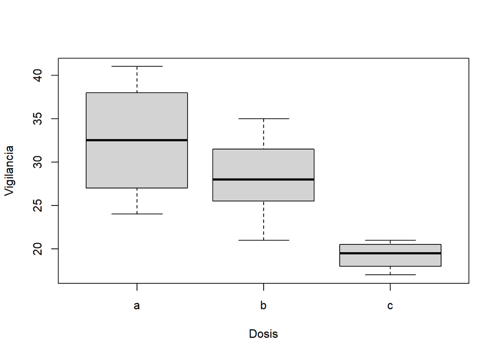

Medias de cada grupo:

```
##     a     b     c
## 32.50 28.25 19.25
```

Desviación estándar de cada grupo:

```
##        a        b        c
## 6.595453 4.432026 1.707825
```

En el gráfico se observa una diferencia clara entre el grupo de dosis “c” y los otros dos grupos. Así que posiblemente no exista diferencia significativa entre el grupo de la dosis “a” y alguno(s) de los otros dos grupos.

Además, se aprecia la diferencia de la media del grupo “a” con respecto a los otros dos grupos.

Por ahora, como hay normalidad y homocedasticidad en todas las muestras o grupos: aplicar prueba paramétrica (ANOVA)

2. Objetivo: Verificar si las tres dosis provienen de la misma distribución.
2. Establecer las hipótesis nula y alternativa.

$H_{0}$: Las distribuciones de los 3 grupos son idénticas, (tienen la misma media y varianza)

$H_{1}$: Al menos un grupo proviene de una distribución diferente al menos dos medias difieren de forma significativa.

https://rpubs.com/Joaquin_AR/219148

3. Decidir una tasa de error aceptable.

   $\alpha$ = 0.05
4. Calcular la prueba estadística de los datos. (**ANOVA**)

```
##             Df Sum Sq Mean Sq F value  Pr(>F)
## Dosis        2  426.2  213.12   8.789 0.00298 **
## Residuals   15  363.8   24.25
## ---
## Signif. codes:  0 '***' 0.001 '**' 0.01 '*' 0.05 '.' 0.1 ' ' 1
```

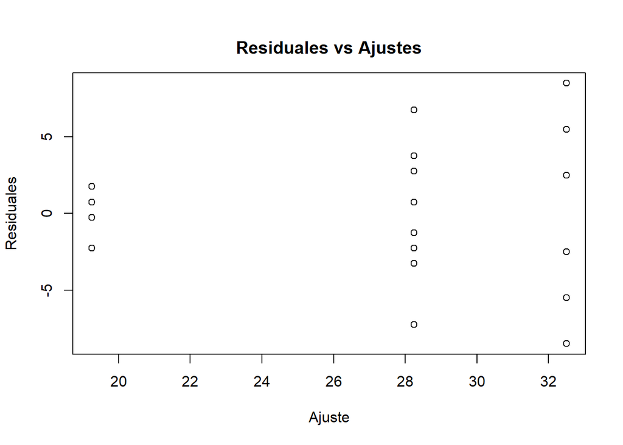

5. Calcular el valor de *p*.

*p* = 0.0029773

6. Rechazar la hipótesis nula si *p* ≤ $\alpha$.

**Análisis complementario**

Debido a que el ANOVA resultó significativo, se puede aplicar el método de Tukey para determinar entre cuales factores hay diferencias significativas, si es que las hay.

```
##   Tukey multiple comparisons of means
##     95% family-wise confidence level
##
## Fit: aov(formula = Vigilancia ~ Dosis)
##
## $Dosis
##       diff       lwr       upr     p adj
## b-a  -4.25 -11.15796  2.657961 0.2768132
## c-a -13.25 -21.50659 -4.993408 0.0022342
## c-b  -9.00 -16.83289 -1.167109 0.0237003
```

Las diferencias entre medias en las que el intervalo de confianza no contiene el valor 0, son estadísticamente significativas con el método de Tukey. En el presente caso, esto se observa en las diferencias entre los grupos “b” y “c” y entre los grupos “a” y “c”. En cambio, el intervalo de confianza de la diferencia entre los grupos “a” y “b”, no es estadísticamente significativo ya que incluye al 0.

Esto puede verse también trazando los intervalos de confianza gráficamente.

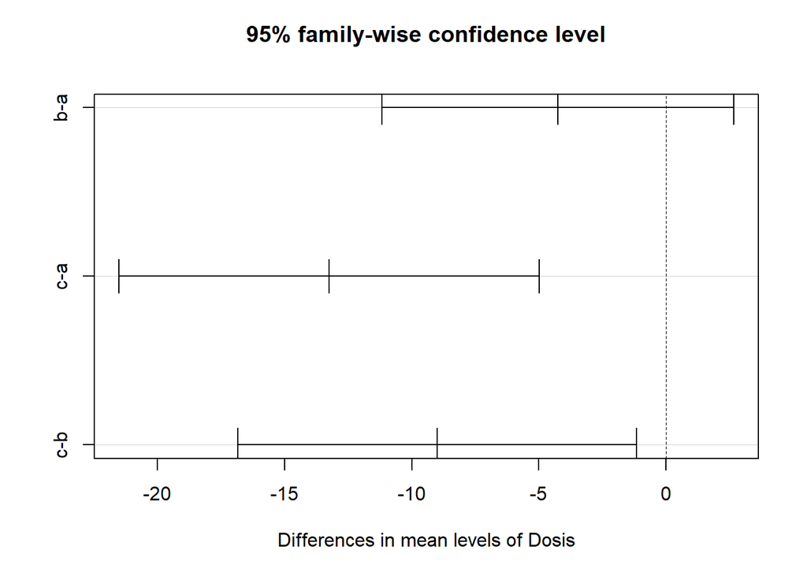

## Ejemplo 16.

Se miden los coliformes totales, en organismos por 100 ml. Aquí se presenta un pequeño subconjunto de ellos. ¿Las cuatro estaciones exhiben valores similares?, o ¿una o más estaciones difieren?

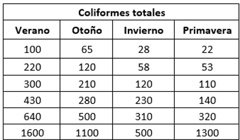

Ejemplo 16

| grupo | y |
| --- | --- |
| Verano | 100 |
| Verano | 220 |
| Verano | 300 |
| Verano | 430 |
| Verano | 640 |
| Verano | 1600 |
| Primavera | 65 |
| Primavera | 120 |
| Primavera | 210 |
| Primavera | 280 |

[output cut: 14 more lines]

1. Seleccionar la prueba apropiada
   1. Prueba paramétrica o no paramétrica.

Haciendo un análisis estadístico descriptivo preliminar se tiene lo siguiente:

Medias de las muestras:

```
##    Verano Primavera     Otoño  Invierno
##  548.3333  379.1667  207.6667  324.1667
```

Medianas de las muestras:

```
##    Verano Primavera     Otoño  Invierno
##       365       245       175       125
```

Desviación estándar de las muestras:

```
##    Verano Primavera     Otoño  Invierno
##  547.5186  384.3230  178.2107  489.2625
```

Diagramas de caja de las muestras:

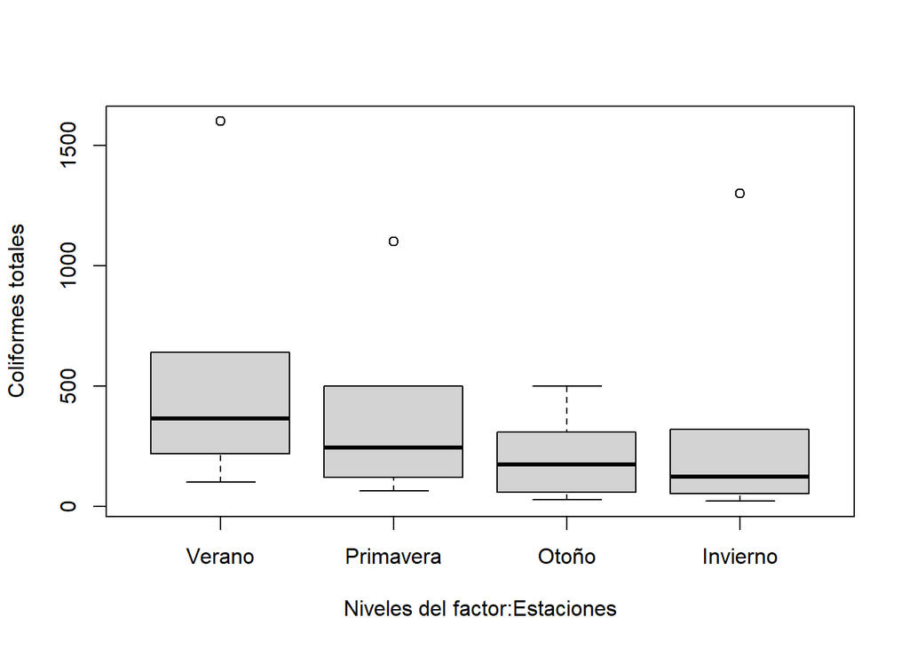

Pruebas de normalidad de las muestras.

Verano:

```
##
##  Shapiro-Wilk normality test
##
## data:  Verano
## W = 0.79824, p-value = 0.05666
```

```
##
##  Lilliefors (Kolmogorov-Smirnov) normality test
##
## data:  Verano
## D = 0.26685, p-value = 0.1987
```

Otoño:

```
##
##  Shapiro-Wilk normality test
##
## data:  Otono
## W = 0.82027, p-value = 0.08873
```

```
##
##  Lilliefors (Kolmogorov-Smirnov) normality test
##
## data:  Otono
## D = 0.26847, p-value = 0.1917
```

Invierno:

```
##
##  Shapiro-Wilk normality test
##
## data:  Invierno
## W = 0.92825, p-value = 0.5667
```

```
##
##  Lilliefors (Kolmogorov-Smirnov) normality test
##
## data:  Invierno
## D = 0.18861, p-value = 0.7228
```

Primavera:

```
##
##  Shapiro-Wilk normality test
##
## data:  Primavera
## W = 0.67572, p-value = 0.003395
```

```
##
##  Lilliefors (Kolmogorov-Smirnov) normality test
##
## data:  Primavera
## D = 0.33673, p-value = 0.03218
```

2. Verificar si las cuatro estaciones provienen de la misma distribución.
2. Establecer las hipótesis nula y alternativa.

$H_{0}$: Las distribuciones de los 4 grupos son idénticas,

$H_{1}$: Al menos un grupo proviene de una distribución diferente (prueba de dos colas).

ó

$H_{0}$: Las medianas de los 4 grupos son idénticas,

$H_{1}$: Al menos una mediana difiere de las otras (prueba de dos colas).

3. Decidir una tasa de error aceptable.

   $\alpha$ = 0.05
4. Calcular la prueba estadística Kruskal-Wallis de los datos.

```
##
##  Kruskal-Wallis rank sum test
##
## data:  y by grupo
## Kruskal-Wallis chi-squared = 2.689, df = 3, p-value = 0.4421
```

5. Calcular el valor de *p*.

*p* = 0.442099

6. Rechazar la hipótesis si *p* ≤ $\alpha$.

Como *p*(0.442099) > $\alpha$ (0.05), no rechazar $H_{0}$. Provienen de la misma distribución.

## Ejemplo 17.

Analizar el nivel de vigilancia entre mujeres(m) y hombres (h) a los que se les ha dado dos posibles niveles de dosis de una droga.

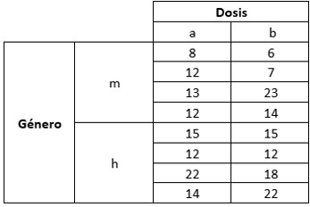

Ejemplo 17

https://www.uv.es/mperea/R-Anovas.html https://rpubs.com/Joaquin_AR/219148

| grupo | y |
| --- | --- |
| Genero | m |
| Genero | m |
| Genero | m |
| Genero | m |
| Genero | m |
| Genero | m |
| Genero | m |
| Genero | m |
| Genero | h |
| Genero | h |

[output cut: 38 more lines]

La prueba determinará si los niveles de vigilancia promedio son idénticos entre todos los 4 grupos de tratamiento, o si al menos uno de ello difiere.

1. Seleccionar la prueba apropiada
1. Prueba paramétrica o no paramétrica.

Normalidad para Vigilancia de Dosis a:

```
##
##  Shapiro-Wilk normality test
##
## data:  a
## W = 0.86214, p-value = 0.1261
```

```
##
##  Anderson-Darling normality test
##
## data:  a
## A = 0.60822, p-value = 0.07299
```

```
##
##  Lilliefors (Kolmogorov-Smirnov) normality test
##
## data:  a
## D = 0.22883, p-value = 0.2497
```

Normalidad para Vigilancia de la Dosis b:

```
##
##  Shapiro-Wilk normality test
##
## data:  b
## W = 0.944, p-value = 0.6508
```

```
##
##  Anderson-Darling normality test
##
## data:  b
## A = 0.20753, p-value = 0.7943
```

```
##
##  Lilliefors (Kolmogorov-Smirnov) normality test
##
## data:  b
## D = 0.13774, p-value = 0.9262
```

Ambas vigilancias provienen de población normal $\therefore$ Paramétrica.

2. Objetivo de la prueba.

   Determinar si las medias de todos los grupos de tratamientos son iguales.
2. Establecer las hipótesis nula y alternativa.

$H_{0}$: todas las medias grupales de los tratamientos son iguales

$H_{1}$: al menos una media difiere del resto

3. Decidir la tasa de error aceptable $\alpha$ = 0.01
4. Calcular la prueba estadística de los datos, ANOVA.

```
##              Df Sum Sq Mean Sq F value Pr(>F)
## Genero        1  76.56   76.56   2.952  0.111
## Dosis         1   5.06    5.06   0.195  0.666
## Genero:Dosis  1   0.06    0.06   0.002  0.962
## Residuals    12 311.25   25.94
```

Calcular el valor de *p*.

*p* = 0.1114507  
*p* = 0.6664956  
*p* = 0.9616567

6. Rechazar la hipótesis nula si *p* ≤ $\alpha$

Como ningún valor de *p* es menor que $\alpha$, se concluye que ni los efectos de los factores o tratamientos Dosis y Género, ni su interacción son altamente significativos en este experimento de vigilancia.

## Ejemplo 18.

Para la ciudad de Monterrey se muestrearon 12 hospitales. En cada uno se obtuvo una muestra del peso al nacer de 6 niños y 6 niñas y se calculó el promedio en cada hospital para cada sexo; dicho promedio fue considerado como la variable para estudiar la variación entre hospitales y entre sexos (observar que se tendría una sola repetición para cada combinación de tratamiento).

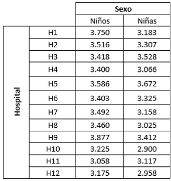

Ejemplo 18

En este caso no se puede probar normalidad debido a que hay una sola repetición en cada grupo de tratamiento. Sin embargo, se supondrá un análisis paramétrico y se concluirá sobre los resultados que se obtengan.

| Hospital | Sexo | Peso |
| --- | --- | --- |
| H1 | Nino | 3.750 |
| H2 | Nino | 3.516 |
| H3 | Nino | 3.418 |
| H4 | Nino | 3.400 |
| H5 | Nino | 3.586 |
| H6 | Nino | 3.403 |
| H7 | Nino | 3.492 |
| H8 | Nino | 3.460 |
| H9 | Nino | 3.877 |
| H10 | Nino | 3.225 |

[output cut: 14 more lines]

1. Seleccionar la prueba apropiada
1. Prueba paramétrica o no paramétrica.

Prueba de normalidad en niños:

```
##
##  Shapiro-Wilk normality test
##
## data:  a
## W = 0.97118, p-value = 0.9228
```

```
##
##  Anderson-Darling normality test
##
## data:  a
## A = 0.24095, p-value = 0.7122
```

```
##
##  Lilliefors (Kolmogorov-Smirnov) normality test
##
## data:  a
## D = 0.16965, p-value = 0.4435
```

Prueba de normalidad en niñas:

```
##
##  Shapiro-Wilk normality test
##
## data:  b
## W = 0.96363, p-value = 0.8341
```

```
##
##  Anderson-Darling normality test
##
## data:  b
## A = 0.1999, p-value = 0.8472
```

```
##
##  Lilliefors (Kolmogorov-Smirnov) normality test
##
## data:  b
## D = 0.14765, p-value = 0.6665
```

Prueba paramétrica.

2. Objetivo de la prueba.

   Determinar si las medias de todos los tratamientos son iguales.
2. Establecer las hipótesis nula y alternativa.

$H_{0}$: todas las medias grupales de los tratamientos son iguales

$H_{1}$: al menos una media difiere del resto

3. Decidir la tasa de error aceptable $\alpha$

$\alpha$ = 0.01

4. Calcular la prueba estadística de los datos (*ANOVA*)

Considerando que sí existe interacción entre hospital y sexo:

|  | Df | Sum Sq | Mean Sq | F value | Pr(>F) |
| --- | --- | --- | --- | --- | --- |
| Hospital | 11 | 0.9038065 | 0.08216422 | NaN | NaN |
| Sexo | 1 | 0.3057784 | 0.30577838 | NaN | NaN |
| Hospital:Sexo | 11 | 0.2819751 | 0.02563410 | NaN | NaN |
| Residuals | 0 | 0.0000000 | NaN | NA | NA |

Considerando que no existe interacción entre hospital y sexo:

|  | Df | Sum Sq | Mean Sq | F value | Pr(>F) |
| --- | --- | --- | --- | --- | --- |
| Hospital | 11 | 0.9038065 | 0.08216422 | 3.20527 | 0.032901138 |
| Sexo | 1 | 0.3057784 | 0.30577838 | 11.92858 | 0.005392005 |
| Residuals | 11 | 0.2819751 | 0.02563410 | NA | NA |

Como se observa, no se puede analizar la interacción de los dos factores. Esto porque el factor Hospital tiene 12 niveles de una sola repetición; es decir, *n* = 1. Entonces, se provoca que no exista valor residual y las pruebas F del ANOVA solo deben considerar los efectos de los factores Hospital y Sexo, sin su interacción. Es por ello que el problema se resuelve sin considerar precisamente la interacción de los factores.

## Ejemplo 19.

Hongos enriquecidos fueron medidos en una escala del 1 al 10 en cuatro diferentes especies de árboles por un período de cuatro días, resultando lo mostrado en la tabla. Investigar si existe diferencia significativa en los hongos enriquecidos entre los árboles .

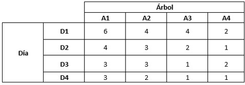

Ejemplo 19

| Dia | Arbol | Calificacion |
| --- | --- | --- |
| D1 | A1 | 6 |
| D2 | A1 | 4 |
| D3 | A1 | 3 |
| D4 | A1 | 3 |
| D1 | A2 | 4 |
| D2 | A2 | 3 |
| D3 | A2 | 3 |
| D4 | A2 | 2 |
| D1 | A3 | 4 |
| D2 | A3 | 2 |

[output cut: 6 more lines]

1. Seleccionar la prueba apropiada.
1. Prueba paramétrica o no paramétrica.

Pruebas de normalidad:

```
##
##  Shapiro-Wilk normality test
##
## data:  a
## W = 0.82743, p-value = 0.1612
```

```
##
##  Shapiro-Wilk normality test
##
## data:  b
## W = 0.94466, p-value = 0.683
```

```
##
##  Shapiro-Wilk normality test
##
## data:  c
## W = 0.82743, p-value = 0.1612
```

```
##
##  Shapiro-Wilk normality test
##
## data:  d
## W = 0.72863, p-value = 0.02386
```

Como se aprecia, la calificación del hongo en la cuarta especie de árbol se comporta no normalmente.

Por lo tanto, prueba no paramétrica

2. Objetivo de la prueba. Verificar la igualdad de las medianas de las calificaciones de todas las especies de árboles.
2. Establecer las hipótesis nula y alternativa.

$H_{0}$: Las medianas de los 4 grupos de calificaciones de los árboles son idénticas.

$H_{1}$: Al menos una mediana es significativamente diferente.

3. Decidir una tasa de error aceptable, $\alpha$.

   $\alpha$ = 0.05
4. Calcular la prueba estadística de los datos. (**Prueba de Friedman**)

```
##
##  Friedman rank sum test
##
## data:  Calificacion and Arbol and Dia
## Friedman chi-squared = 10.297, df = 3, p-value = 0.0162
```

https://rpubs.com/Joaquin_AR/219732

*Cuando no existe normalidad en los datos de los grupos de tratamiento y tampoco tienen varianzas iguales se aplican técnicas no paramétricas como la de Kruskall-Wallis, friedman, Mann-Whitney-Wilcoxon, de signo de Wilcoxon. Es importante mencionar que con pruebas como esta no se obtienen resultados de interacciones entre los factores.*

# COMPARACIÓN DE VARIOS GRUPOS DEPENDIENTES (dos factores o tratamientos).

## Ejemplo 20

Una empresa de agua buscó si fueron efectivas las pruebas adoptadas para limpiar un río. Se tomaron las demandas bioquímicas de oxígeno (DBO) en 12 sitios en el río, antes, al mes y al año después de la limpieza. A continuación se muestran los resultados:

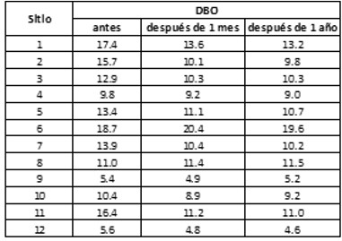

Ejemplo 20

| Fecha | Sitio | DBO |
| --- | --- | --- |
| antes | 1 | 17.4 |
| antes | 2 | 15.7 |
| antes | 3 | 12.9 |
| antes | 4 | 9.8 |
| antes | 5 | 13.4 |
| antes | 6 | 18.7 |
| antes | 7 | 13.9 |
| antes | 8 | 11.0 |
| antes | 9 | 5.4 |
| antes | 10 | 10.4 |

[output cut: 26 more lines]

1. Seleccionar la prueba apropiada.
   1. Prueba paramétrica o no paramétrica.

| Fecha | Sitio | DBO |
| --- | --- | --- |
| antes | 1 | 17.4 |
| antes | 2 | 15.7 |
| antes | 3 | 12.9 |
| antes | 4 | 9.8 |
| antes | 5 | 13.4 |
| antes | 6 | 18.7 |
| antes | 7 | 13.9 |
| antes | 8 | 11.0 |
| antes | 9 | 5.4 |
| antes | 10 | 10.4 |

[output cut: 26 more lines]

Pruebas de normalidad.

Normalidad en “antes:”

```
##
##  Shapiro-Wilk normality test
##
## data:  a
## W = 0.94989, p-value = 0.6354
```

```
##
##  Anderson-Darling normality test
##
## data:  a
## A = 0.23186, p-value = 0.7447
```

```
##
##  Lilliefors (Kolmogorov-Smirnov) normality test
##
## data:  a
## D = 0.11582, p-value = 0.9278
```

Normalidad en “después de un mes:”

```
##
##  Shapiro-Wilk normality test
##
## data:  b
## W = 0.87045, p-value = 0.06622
```

```
##
##  Anderson-Darling normality test
##
## data:  b
## A = 0.70337, p-value = 0.04857
```

```
##
##  Lilliefors (Kolmogorov-Smirnov) normality test
##
## data:  b
## D = 0.24714, p-value = 0.04139
```

Normalidad en “después de un año:”

```
##
##  Shapiro-Wilk normality test
##
## data:  c
## W = 0.88245, p-value = 0.09421
```

```
##
##  Anderson-Darling normality test
##
## data:  c
## A = 0.66619, p-value = 0.06099
```

```
##
##  Lilliefors (Kolmogorov-Smirnov) normality test
##
## data:  c
## D = 0.21517, p-value = 0.1299
```

“Después de un mes” no cumple con normalidad por muy poco. Por lo tanto, prueba no paramétrica.

```
b) Objetivo de la prueba. Analizar la diferencia entre las medias poblacionales de cada muestra medida antes, al mes y al año.
```

2. Establecer las hipótesis nula y alternativa.

   $H_{0}$: Las medias de los 3 grupos de tratamiento son iguales.

   $H_{1}$: Al menos una media es significativamente diferente.

Es decir, en caso de que las medias de los tres grupos conserven la misma media poblacional, que no se rechace $H_{0}$, significaría que no se logró ningún cambio con las medidas adoptadas para limpiar el río.

3. Definir una tasa de error aceptable.

   $\alpha$ = 0.05
4. Calcular la prueba estadística de los datos. ( *Prueba de Friedman* )

```
##
##  Friedman rank sum test
##
## data:  DBO and Fecha and Sitio
## Friedman chi-squared = 9.234, df = 2, p-value = 0.009882
```

5. Calcular el valor de *p*.

*p*(0.0098822)

6. Rechazar la hipótesis nula si *p* ≤ $\alpha$.

Si el valor de *p*(0.0098822) < 0.05, se rechaza $H_{0}$. Y se concluye que el tratamiento ha tenido un efecto significativo sobre la DBO para ese tramo del río. Caso contrario, se acepta $H_{0}$.

## Ejemplo 21

Con objeto de estudiar la diferencia de concentración de un tóxico (mg/1000) en distintos órganos de peces, se extrae una muestra aleatoria de peces de un río y se estudia en cada uno de ellos la concentración del tóxico (mg/1000) en cerebro corazón y sangre. El objetivo del estudio es conocer si la concentración del tóxico en los tres órganos es igual o distinta. Los resultados obtenidos son los siguientes:

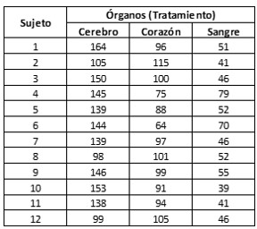

Ejemplo 21

| Organo | Sujeto | Concentracion |
| --- | --- | --- |
| Cerebro | S1 | 164 |
| Cerebro | S2 | 105 |
| Cerebro | S3 | 150 |
| Cerebro | S4 | 145 |
| Cerebro | S5 | 139 |
| Cerebro | S6 | 144 |
| Cerebro | S7 | 139 |
| Cerebro | S8 | 98 |
| Cerebro | S9 | 146 |
| Cerebro | S10 | 153 |

[output cut: 26 more lines]

1. Seleccionar la prueba apropiada.
   1. Prueba paramétrica o no paramétrica.

Pruebas de normalidad.

Normalidad en “Cerebro:”

```
##
##  Shapiro-Wilk normality test
##
## data:  a
## W = 0.83775, p-value = 0.026
```

```
##
##  Anderson-Darling normality test
##
## data:  a
## A = 0.94749, p-value = 0.0109
```

```
##
##  Lilliefors (Kolmogorov-Smirnov) normality test
##
## data:  a
## D = 0.30437, p-value = 0.003037
```

Normalidad en “Corazón:”

```
##
##  Shapiro-Wilk normality test
##
## data:  b
## W = 0.92332, p-value = 0.3146
```

```
##
##  Anderson-Darling normality test
##
## data:  b
## A = 0.49466, p-value = 0.1726
```

```
##
##  Lilliefors (Kolmogorov-Smirnov) normality test
##
## data:  b
## D = 0.17408, p-value = 0.4019
```

Normalidad en “Sangre:”

```
##
##  Shapiro-Wilk normality test
##
## data:  c
## W = 0.84304, p-value = 0.03016
```

```
##
##  Anderson-Darling normality test
##
## data:  c
## A = 0.77959, p-value = 0.03045
```

```
##
##  Lilliefors (Kolmogorov-Smirnov) normality test
##
## data:  c
## D = 0.23336, p-value = 0.07015
```

Debido a que no se cumple en todos los factores la normalidad, sse considera una prueba no paramétrica.

```
b) Objetivo de la prueba. Analizar la diferencia entre las medias poblacionales de cada muestra medida en cerebro, corazón y sangre.
```

2. Establecer las hipótesis nula y alternativa.

   $H_{0}$: Las medias de los 3 grupos son iguales.

   $H_{1}$: Al menos una media es significativamente diferente.
3. Definir una tasa de error aceptable.

   $\alpha$ = 0.05
4. Calcular la prueba estadística de los datos.

```
##
##  Friedman rank sum test
##
## data:  Concentracion and Organo and Sujeto
## Friedman chi-squared = 15.167, df = 2, p-value = 0.0005089
```

5. Calcular el valor de *p*.

*p*(5.0886219^{-4})

6. Rechazar la hipótesis nula si *p* ≤ $\alpha$.

Si el valor de *p*(5.0886219^{-4}) < 0.05, se rechaza H0. Y se concluye que existen diferencias significativas en la concentración del tóxico en cerebro, corazón y sangre. Caso contrario, se acepta $H_{0}$.

# CORRELACIÓN

Los coeficientes de correlación son una medida de la fuerza de asociación entre dos variables continuas. Es muy importante elaborar un diagrama de dispersión inicial de los datos. De esta forma se pueda tener información visual a través de una gráfica. La relevancia de este paso inicial puede apreciarse en la siguiente figura, en donde se pueden tener coeficientes de correlación similares, pero los datos son muy diferentes.

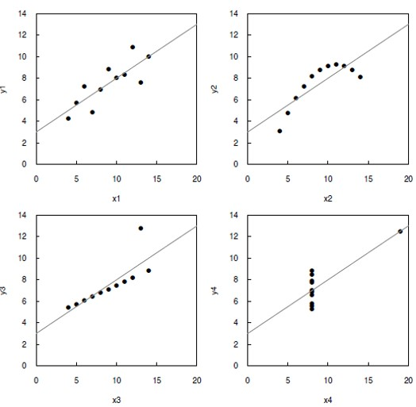

Ejemplo 22

Cuatro diagramas de dispersión de conjuntos de datos que tienen las mismas propiedades estadísticas tradicionales de media, varianza, correlación, intersección de regresión *x*- *y* y coeficiente. Estos conjuntos de datos se conocen como el cuarteto de Anscombe (Anscombe, 1973).

## Ejemplo 22. (*r* de Pearson)

Se tienen 10 pares de datos dados abajo, ordenados de manera creciente con respecto de *x*.

| x | y |
| --- | --- |
| 2 | 1.22 |
| 24 | 2.20 |
| 99 | 4.80 |
| 197 | 1.28 |
| 377 | 1.97 |
| 544 | 1.46 |
| 632 | 2.64 |
| 3452 | 2.34 |
| 6587 | 4.84 |
| 53170 | 2.96 |

[figure not shown]

1. Seleccionar la prueba apropiada
   1. Del comportamiento de la relación entre las dos variables, mostrado en la figura anterior, se puede suponer que es no paramétrico debido al punto disparado. Sin embargo, se aplica esta prueba *r* de Pearson paramétrica con fines pedagógicos.

También, comprobando normalidad de ambas variables *x* *y* y se obtiene:

Para *x*:

```
##
##  Shapiro-Wilk normality test
##
## data:  x
## W = 0.45466, p-value = 1.074e-06
```

Si *p*(1.0739943^{-6}) > $\alpha$(0.05) no hay evidencia para rechazar la hipótesis de normalidad, caso contrario, se rechaza.

Para *y*:

```
##
##  Shapiro-Wilk normality test
##
## data:  y
## W = 0.85397, p-value = 0.06476
```

Si *p*(0.0647592) > $\alpha$(0.05) no hay evidencia para rechazar la hipótesis de normalidad, caso contrario, se rechaza.

Como se aprecia, solamente *y* cumple con normalidad, usando $\alpha$=0.05. Por lo que se confirma la suposición de que sea más adecuado aplicar las pruebas $\tau$ de Kendall y/o $\rho$ de Spearman. Sin embargo, se proseguirá con el ejemplo para fines didácticos, considerando que se aplica la prueba paramétrica *r* de Pearson.

2. Determinar la fuerza de relación monótona de dos variables.
2. Establecer las hipótesis nula y alternativa.

   $H_{0}$: No existe correlación entre *x* y *y* (*r*=0)

   $H_{1}$: *x* y *y* están correlacionadas (*r* $\neq$ 0)
3. Decidir una tasa de error aceptable

   $\alpha$ = 0.05
4. Calcular la prueba estadística con los datos.

```
##
##  Pearson's product-moment correlation
##
## data:  x and y
## t = 0.49929, df = 8, p-value = 0.631
## alternative hypothesis: true correlation is not equal to 0
## 95 percent confidence interval:
##  -0.5118066  0.7241990
## sample estimates:
##       cor
## 0.1738387
```

5. Calcular el valor de *p*.

*p* = 0.6310127

6. Rechazar la hipótesis nula si *p* ≤ $\alpha$.

   Se acepta la hipótesis nula. No existe correlación lineal entre *x* y *y*. Como se observa, al aplicar *r* de Pearson es evidente la falta de correlación (0.1738387); esto puede deberse al punto disparado en la variable *x*, lo que impacta en la relación lineal entre *x* y *y*.

## Ejemplo 22 (cont.). ($\tau$ de Kendall)

Resolver con Kendall.

1. Seleccionar la prueba apropiada
1. Del comportamiento de la relación entre las dos variables, se puede suponer que es no paramétrico debido al punto disparado. Además de la no normalidad de la variable *x*.
2. Determinar la fuerza de relación monótona de dos variables.
2. Establecer las hipótesis nula y alternativa.

$H_{0}$: No existe correlación entre *x* y *y* ($\tau$=0)

$H_{1}$: *x* y *y* están correlacionadas ($\tau \neq$ 0)

3. Decidir una tasa de error aceptable

   $\alpha$ = 0.05
4. Calcular la prueba estadística de los datos. Aplicando $\tau$ de Kendall.

```
##
##  Kendall's rank correlation tau
##
## data:  x and y
## T = 33, p-value = 0.07255
## alternative hypothesis: true tau is not equal to 0
## sample estimates:
##       tau
## 0.4666667
```

5. Calcular el valor de *p*.

*p* = 0.0725502

6. Rechazar la hipótesis nula si *p* ≤ $\alpha$.

Entonces como *p* (0.0725502) > $\alpha$ (0.05) se acepta $H_{0}$. No existe correlación monótona (no lineal) entre *x* y *y*. $\tau$ = 0.4666667.

## Ejemplo 22 (cont.). ($\rho$ de Spearman)

Resolver con Spearman.

1. Seleccionar la prueba apropiada
1. Del comportamiento de la relación entre las dos variables, se puede suponer que es no paramétrico debido al punto disparado. Además de la no normalidad de la variable *x*.
2. Determinar la fuerza de relación monótona de dos variables.
2. Establecer las hipótesis nula y alternativa.

$H_{0}$: No existe correlación entre *x* y *y* ($\rho$=0)

$H_{1}$: *x* y *y* están correlacionadas ($\rho \neq$ 0)

3. Decidir una tasa de error aceptable

   $\alpha$ = 0.05
4. Calcular la prueba estadística de los datos. Aplicando $\tau$ de Spearman.

```
##
##  Spearman's rank correlation rho
##
## data:  x and y
## S = 68, p-value = 0.08022
## alternative hypothesis: true rho is not equal to 0
## sample estimates:
##       rho
## 0.5878788
```

5. Calcular el valor de *p*.

*p* = 0.0802151

6. Rechazar la hipótesis nula si *p* ≤ $\alpha$.

Entonces como *p* (0.0802151) > $\alpha$ (0.05) se acepta $H_{0}$. No existe correlación monótona (no lineal) entre *x* y *y*. $\rho$ = 0.5878788.

**Finalmente se puede comentar que considerando los valores de *p* obtenidos para *r*, $\tau$ y $\rho$ (0.6310127, 0.0725502 y 0.0802151, respectivamente) indicaron el grado de asociación entre y y x.**

# REGRESIÓN LINEAL SIMPLE

En muchos experimentos se desea investigar cuáles cambios en una variable afectan a otra variable. Existen situaciones en que una relación lineal puede resumir la dependencia observada de una variable sobre otra.

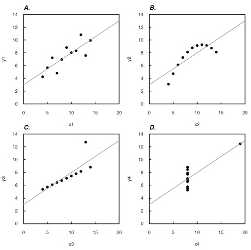

REGRESIÓN LINEAL SIMPLE

Los datos de los cuatro gráficos que se muestran en la figura anterior tienen exactamente las mismas estadísticas de resumen y la misma línea de regresión (mismos $b_{0}$, $b_{1}$, *s* y $R^{2}$). Esta figura muestra que existen tres posibilidades de generar modelos de regresión problemáticos, de alli la importancia de identificar alguna anomalía através de gráficas de *x* vs *y* o de los residuos.

Por otro lado, en la siguiente tabla se muestran cinco condiciones que debe cumplir el modelo de regresión lineal simple, dependiendo su propósito.

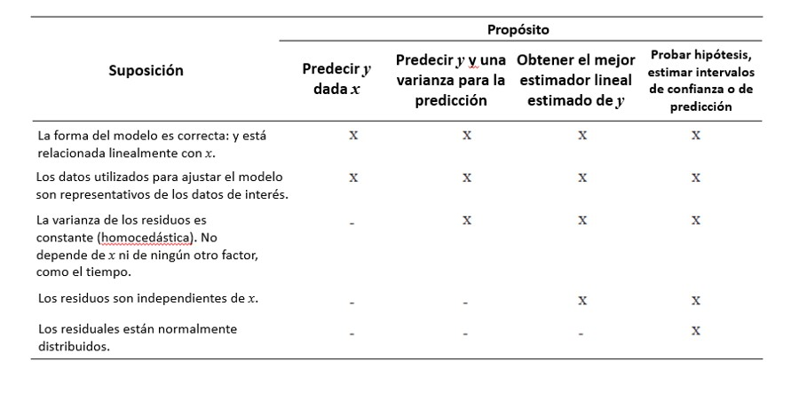

Condiciones para la regresión lineal simple.

https://rpubs.com/joser/RegresionSimple

https://fhernanb.github.io/libro_regresion/

https://rpubs.com/jorge_mendez/532491

## Ejemplo 23

Considerar que se tienen 25 observaciones de dos variables *x* y *y*. Obtener la ecuación lineal simple que relaciona ambas variables: *y = f(x)*.

| x | y |
| --- | --- |
| 35.3 | 10.98 |
| 29.7 | 11.13 |
| 30.8 | 12.51 |
| 58.8 | 8.40 |
| 61.4 | 9.27 |
| 71.3 | 8.73 |
| 74.4 | 6.36 |
| 76.7 | 8.50 |
| 70.7 | 7.82 |
| 57.5 | 9.14 |

[output cut: 15 more lines]

1. Graficar los datos para observar una probable relación lineal entre *x* y *y*.

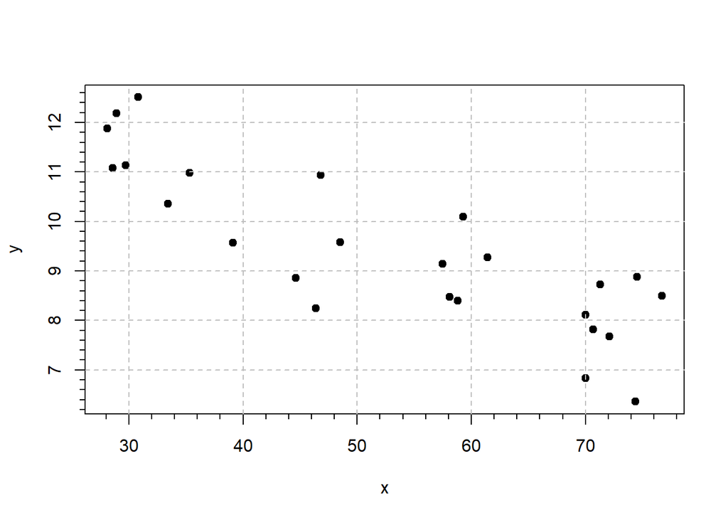

Como se aprecia en la figura anterior, existe la posibilidad de que se exista una relación lineal entre *x* y *y*.

**Cálculo de la regresión lineal simple:**

```
##
## Call:
## lm(formula = y ~ x)
##
## Residuals:
##     Min      1Q  Median      3Q     Max
## -1.6789 -0.5291 -0.1221  0.7988  1.3457
##
## Coefficients:
##             Estimate Std. Error t value Pr(>|t|)
## (Intercept) 13.62299    0.58146  23.429  < 2e-16 ***
## x           -0.07983    0.01052  -7.586 1.05e-07 ***
## ---
## Signif. codes:  0 '***' 0.001 '**' 0.01 '*' 0.05 '.' 0.1 ' ' 1
##
## Residual standard error: 0.8901 on 23 degrees of freedom
## Multiple R-squared:  0.7144, Adjusted R-squared:  0.702
## F-statistic: 57.54 on 1 and 23 DF,  p-value: 1.055e-07
```

Recta ajustada por mínimos cuadrados:

*y* = 13.6229893 + -0.0798287**x*

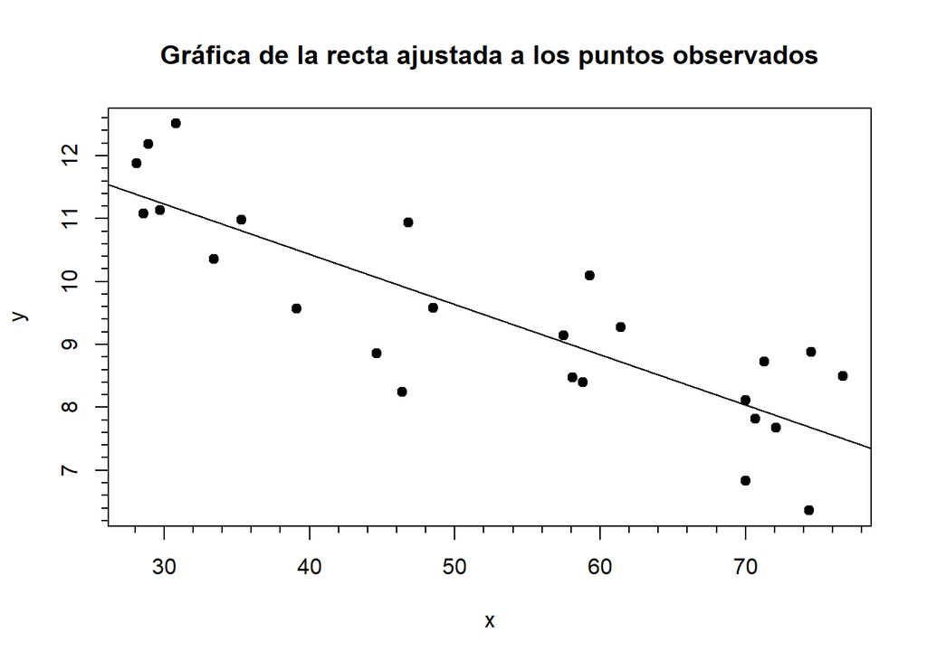

**Diagnóstico de la regresión:**

*Linealidad*: Los residuos deben seguir una distribución normal con media cero. Esta suposición es esencial para probar correctamente las hipótesis y construir intervalos de confianza.

Normalidad de los residuos:

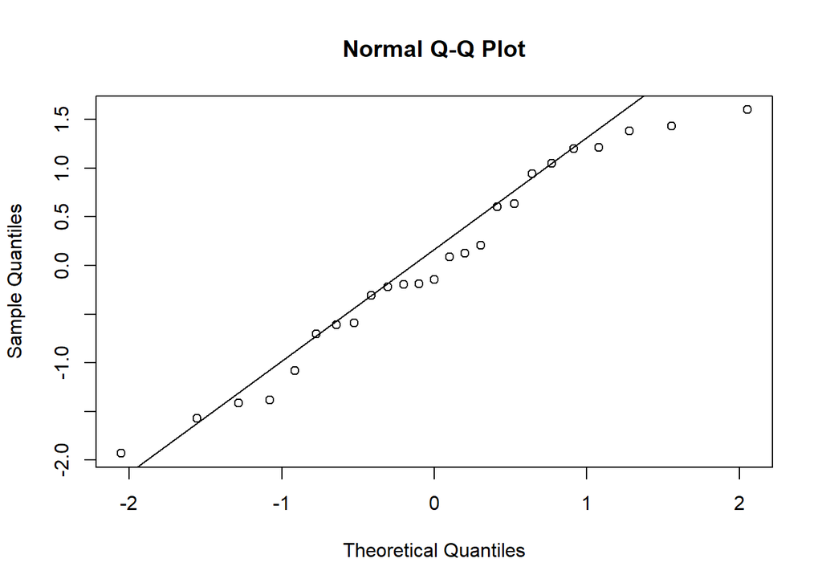

```
##
##  Shapiro-Wilk normality test
##
## data:  residuos
## W = 0.96019, p-value = 0.4183
```

```
##
##  Anderson-Darling normality test
##
## data:  residuos
## A = 0.30326, p-value = 0.5473
```

```
##
##  Lilliefors (Kolmogorov-Smirnov) normality test
##
## data:  residuos
## D = 0.10059, p-value = 0.7402
```

Se cumple con la prueba de normalidad de los residuos.

*Homocedasticidad*: Este supuesto establece que la varianza de los residuos debe ser constante en todos los niveles de variables independientes. En otras palabras, la dispersión de los residuos debería ser similar para todos los valores de las variables independientes.

$H_0$: los errores tienen varianza constante

$H_1$: los errores tienen varianza constante

Prueba de Breusch-Pagan.

```
##
##  studentized Breusch-Pagan test
##
## data:  regresion
## BP = 0.19404, df = 1, p-value = 0.6596
```

Se observa que *p* > $\alpha$(0.05), por lo tanto, hay evidencias para decir que se cumple la homocedasticidad de los $e_{i}$.

*Independencia*: los residuos son independientes.

$H_0$: los errores son independientes

$H_1$: los errores son dependientes

Prueba de Durbin Watson.

```
##
##  Durbin-Watson test
##
## data:  regresion
## DW = 2.7013, p-value = 0.9497
## alternative hypothesis: true autocorrelation is greater than 0
```

Se observa que *p* > $\alpha$(0.05), por lo tanto, hay evidencias para decir que se cumple la independencia de los $e_{i}$.

Además, la representación de los residuos estandarizados frente a los valores ajustados, que resulta útil al llevar a cabo el diagnóstico del modelo:

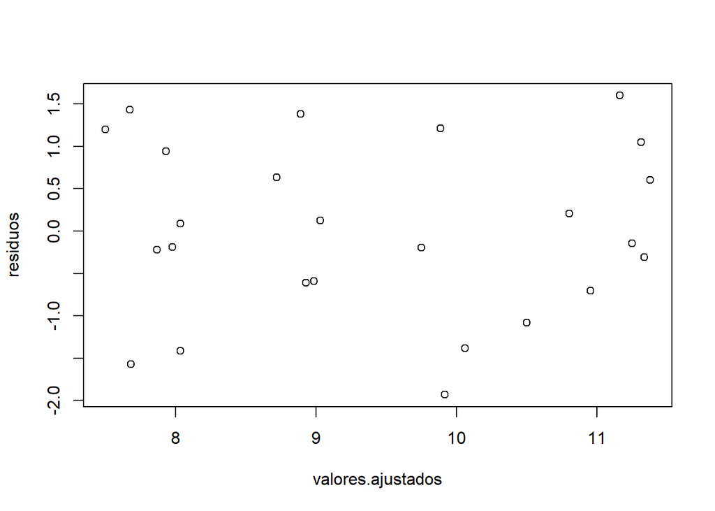

No se observa ningún patrón especial, por lo que tanto la homocedasticidad como la linealidad resultan hipótesis razonables.

Del resultado de la regresión se puede hacer el siguiente análisis:

• Los errores típicos de los parámetros $\beta_{0}$ y $\beta_{1}$ son 0.58146 y 0.01052, respectivamente.

• Prueba de hipótesis cuando la pendiente difiere de cero.

$H_{0}$: $\beta_{1}$ = 0

$H_{1}$: $\beta_{1}\neq$ 0

• Prueba de hipótesis cuando la intercepción difiere de cero.

$H_{0}$: $\beta_{0}$ = 0

$H_{1}$: $\beta_{0}\neq$ 0

• Los intervalos de confianza para los parámetros estimados $\beta_{0}$ y $\beta_{1}$ se obtienen de la siguiente manera:

```
##                  2.5 %      97.5 %
## (Intercept) 12.4201404 14.82583815
## x           -0.1015984 -0.05805901
```

Entonces, los verdaderos valores de $\beta_{0}$ y $\beta_{1}$ caen dentro de los intervalos (12.4201404, 14.82583815) y (-0.1015984 -0.05805901), respectivamente, con un 95% de intervalo de confianza.

Si se desea algún otro intervalo de confianza, como el de 90%

```
##                     5 %        95 %
## (Intercept) 12.62643554 14.61954300
## x           -0.09786476 -0.06179263
```

Debido a que el modelo cumple con las condiciones de linealidad, homocedasticidad e independencia, se puede:

**Predecir *y*:**

Si *x* = 50, entonces la *y* estimada es:

```
## (Intercept)
##    9.631555
```

Ahora, suponer que se quiere calcular las predicciones para [30 $\leq$ *x* $\leq$ 80]

```
##         1         2         3         4         5         6         7         8
## 11.228128 11.148300 11.068471 10.988642 10.908814 10.828985 10.749156 10.669328
##         9        10        11        12        13        14        15        16
## 10.589499 10.509670 10.429842 10.350013 10.270184 10.190355 10.110527 10.030698
##        17        18        19        20        21        22        23        24
##  9.950869  9.871041  9.791212  9.711383  9.631555  9.551726  9.471897  9.392069
##        25        26        27        28        29        30        31        32
##  9.312240  9.232411  9.152582  9.072754  8.992925  8.913096  8.833268  8.753439
##        33        34        35        36        37        38        39        40
##  8.673610  8.593782  8.513953  8.434124  8.354296  8.274467  8.194638  8.114809
##        41        42        43        44        45        46        47        48
##  8.034981  7.955152  7.875323  7.795495  7.715666  7.635837  7.556009  7.476180
##        49        50        51
##  7.396351  7.316522  7.236694
```

La varianza se puede deducir del resultado del modelo de regresión lineal:

```
## [1] 1.04022
```

El coeficiente $R^{2}$ fue de 0.702, lo que significa que la varianza del modelo estaría explicada en un 70.2%, es decir, el modelo es capaz de explicar el valor del 70.2% de las observaciones.

En cuanto al **estimador lineal de *y***, observando los valores obtenidos en el modelo para **p**, se confirma estadísticamente significativo diferente de cero, ya que a su vez, los coeficientes del modelo también son altamante significativos.

https://www.dm.uba.ar/materias/estadistica_Q/2010/2/C014%20Regresion%20Lineal%20Simple%20.pdf

Graficando los valores de la predicción para *x* y *y*, así como sus **intervalos de confianza** y de **predicción**, se obtiene lo siguiente:

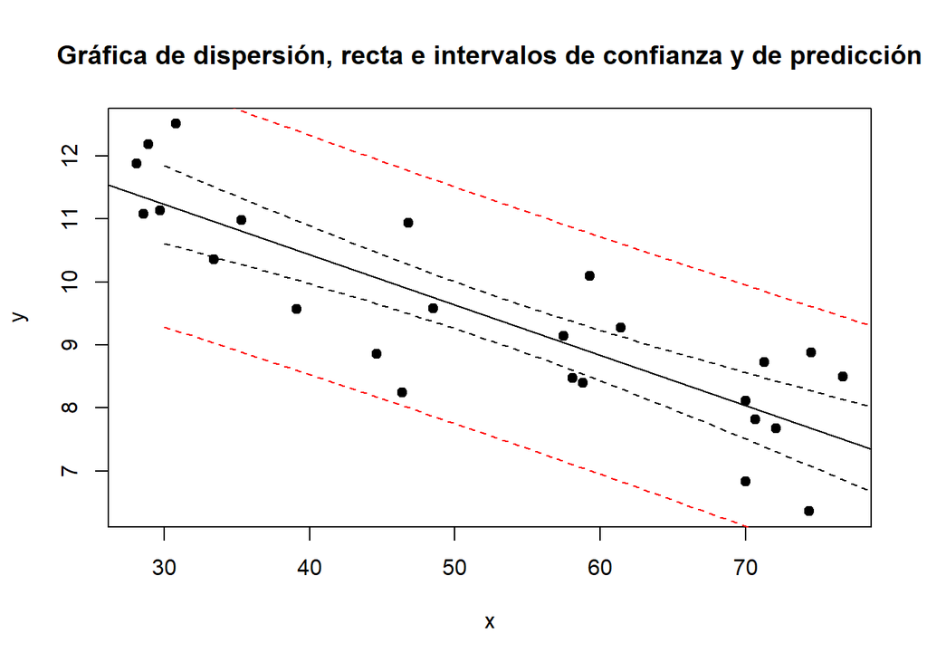

## Ejemplo 24

| X | date | discharge_cms | tds_mgL |
| --- | --- | --- | --- |
| 1 | 24/11/1969 | 9.825946 | 352 |
| 2 | 09/09/1970 | 8.466737 | 728 |
| 3 | 12/10/1970 | 6.654459 | 440 |
| 4 | 31/10/1970 | 9.061391 | 316 |
| 5 | 02/11/1970 | 11.355055 | 334 |
| 6 | 23/11/1970 | 14.838028 | 256 |
| 7 | 15/12/1970 | 23.956052 | 228 |
| 8 | 30/12/1970 | 10.165748 | 314 |
| 9 | 13/01/1971 | 9.910896 | 276 |
| 10 | 30/01/1971 | 5.606736 | 558 |

[output cut: 60 more lines]

1. Graficar los datos para observar una probable relación lineal entre *x*=discharge_cms y *y*=tds_mgL.

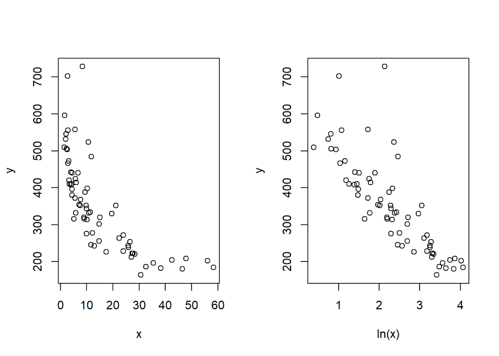

Como se aprecia en la figura anterior, existe la posibilidad de que se exista una relación lineal entre *ln(x)* y *y*.

*x = ln(discharge_cms)*

*y = tds_mgL*

**Cálculo de la regresión lineal simple:**

```
##
## Call:
## lm(formula = y ~ x)
##
## Residuals:
##     Min      1Q  Median      3Q     Max
## -109.89  -42.95  -10.65   13.32  356.91
##
## Coefficients:
##             Estimate Std. Error t value Pr(>|t|)
## (Intercept)  609.549     22.800   26.73   <2e-16 ***
## x           -111.631      9.227  -12.10   <2e-16 ***
## ---
## Signif. codes:  0 '***' 0.001 '**' 0.01 '*' 0.05 '.' 0.1 ' ' 1
##
## Residual standard error: 72.57 on 68 degrees of freedom
## Multiple R-squared:  0.6828, Adjusted R-squared:  0.6781
## F-statistic: 146.4 on 1 and 68 DF,  p-value: < 2.2e-16
```

Recta ajustada por mínimos cuadrados:

*y* = 609.5487272 + -111.631069**x*

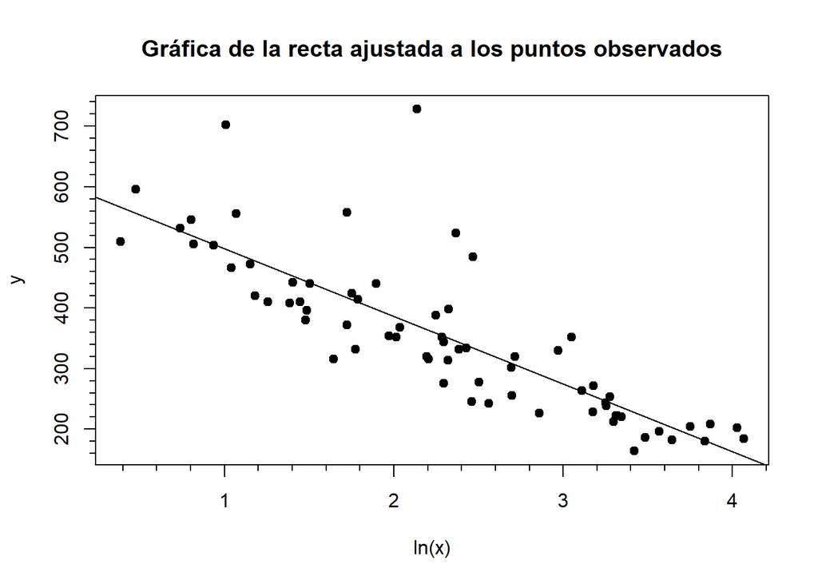

**Diagnóstico de la regresión:**

*Linealidad*: Los residuos deben seguir una distribución normal con media cero. Esta suposición es esencial para probar correctamente las hipótesis y construir intervalos de confianza.

Normalidad de los residuos:

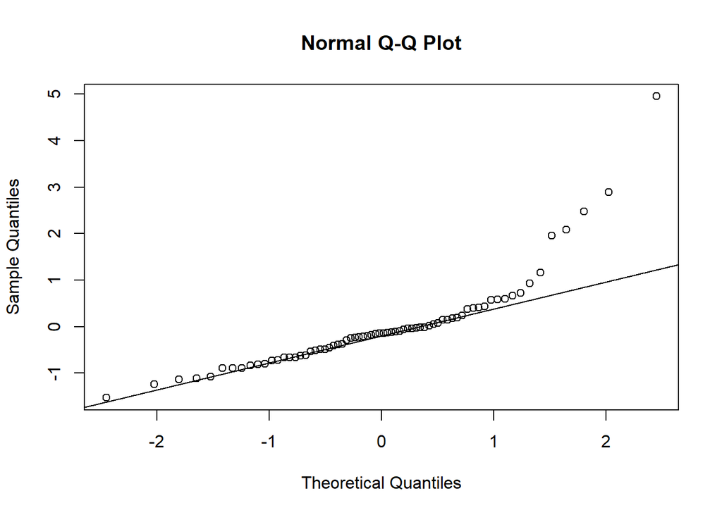

```
##
##  Shapiro-Wilk normality test
##
## data:  residuos
## W = 0.79112, p-value = 1.398e-08
```

```
##
##  Anderson-Darling normality test
##
## data:  residuos
## A = 3.6707, p-value = 2.954e-09
```

```
##
##  Lilliefors (Kolmogorov-Smirnov) normality test
##
## data:  residuos
## D = 0.18336, p-value = 3.901e-06
```

No se cumple con la prueba de normalidad de los residuos (no hay linealidad).

*Homocedasticidad*: Este supuesto establece que la varianza de los residuos debe ser constante en todos los niveles de variables independientes. En otras palabras, la dispersión de los residuos debería ser similar para todos los valores de las variables independientes.

$H_0$: los errores tienen varianza constante

$H_1$: los errores tienen varianza constante

Prueba de Breusch-Pagan.

```
##
##  studentized Breusch-Pagan test
##
## data:  regresion
## BP = 0.52143, df = 1, p-value = 0.4702
```

Se observa que *p* > $\alpha$(0.05), por lo tanto, hay evidencias para decir que se cumple la homocedasticidad de los $e_{i}$.

*Independencia*: los residuos son independientes.

$H_0$: los errores son independientes

$H_1$: los errores son dependientes

Prueba de Durbin Watson.

```
##
##  Durbin-Watson test
##
## data:  regresion
## DW = 1.7451, p-value = 0.1255
## alternative hypothesis: true autocorrelation is greater than 0
```

Se observa que *p* > $\alpha$(0.05), por lo tanto, hay evidencias para decir que se cumple la independencia de los $e_{i}$.

Además, la representación de los residuos estandarizados frente a los valores ajustados, que resulta útil al llevar a cabo el diagnóstico del modelo:

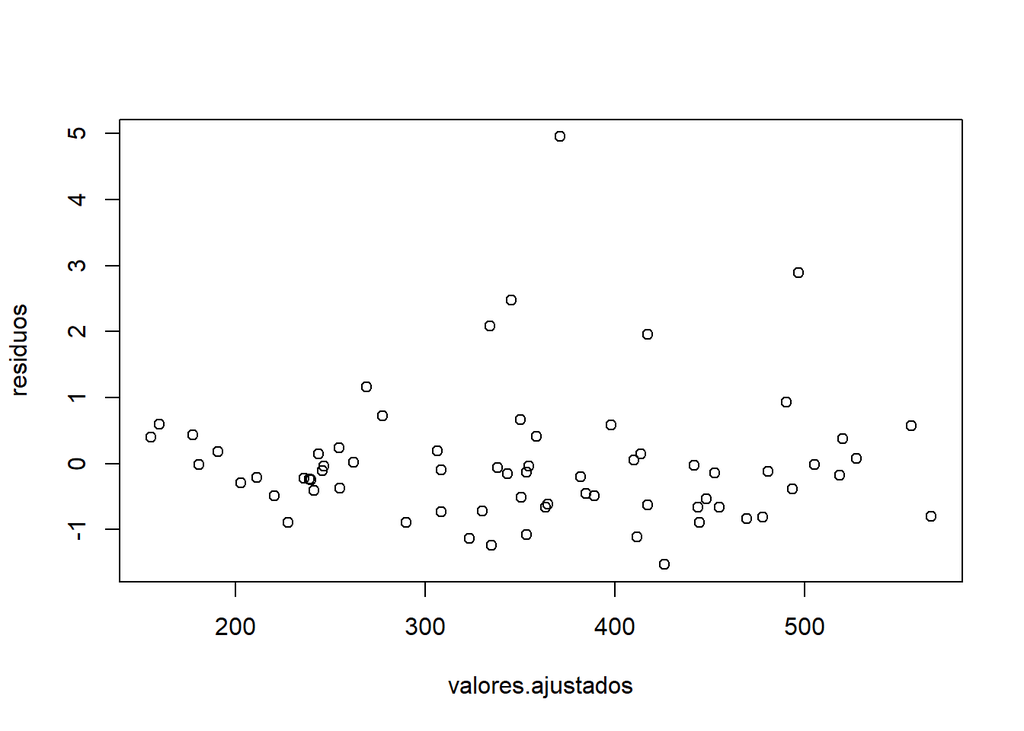

No se observa ningún patrón especial, por lo que la homocedasticidad resulta una hipótesis razonable.

Del resultado de la regresión se puede hacer el siguiente análisis:

• Prueba de hipótesis cuando la pendiente difiere de cero.

$H_{0}$: $\beta_{1}$ = 0

$H_{1}$: $\beta_{1}\neq$ 0

El valor de *p* = < 2e-16. Es decir, se rechaza $H_{0}$ y se acepta $H_{1}$, el valor de $\beta_{1}$ es diferente de cero.

$H_{0}$: $\beta_{0}$ = 0

$H_{1}$: $\beta_{0}\neq$ 0

• Los intervalos de confianza para los parámetros estimados $\beta_{0}$ y $\beta_{1}$ se obtienen de la siguiente manera:

```
##                 2.5 %    97.5 %
## (Intercept)  564.0529 655.04457
## x           -130.0436 -93.21855
```

Si se desea algún otro intervalo de confianza, como el de 90%

```
##                   5 %      95 %
## (Intercept)  571.5288 647.56867
## x           -127.0180 -96.24411
```

Debido a que el modelo no cumple con la condición de linealidad; y si cumple con las condiciones de homocedasticidad e independencia, se puede:

**Predecir *y*:**

No se puede predecir *y*. (No linealidad)

**Entonces, no se puede predecir *y* ni confiar en el valor obtenido en el modelo de la varianza para la predicción**

En cuanto al **estimador lineal de *y***, observando los valores obtenidos en el modelo para **p**, se confirma estadísticamente significativo diferente de cero, ya que a su vez, los coeficientes del modelo también son altamante significativos. Con esto, se pueden obtener intervalos de confianza y de predicción.

Graficando los valores de la predicción para *x* y *y*, así como sus **intervalos de confianza** y de **predicción**, se obtiene lo siguiente:

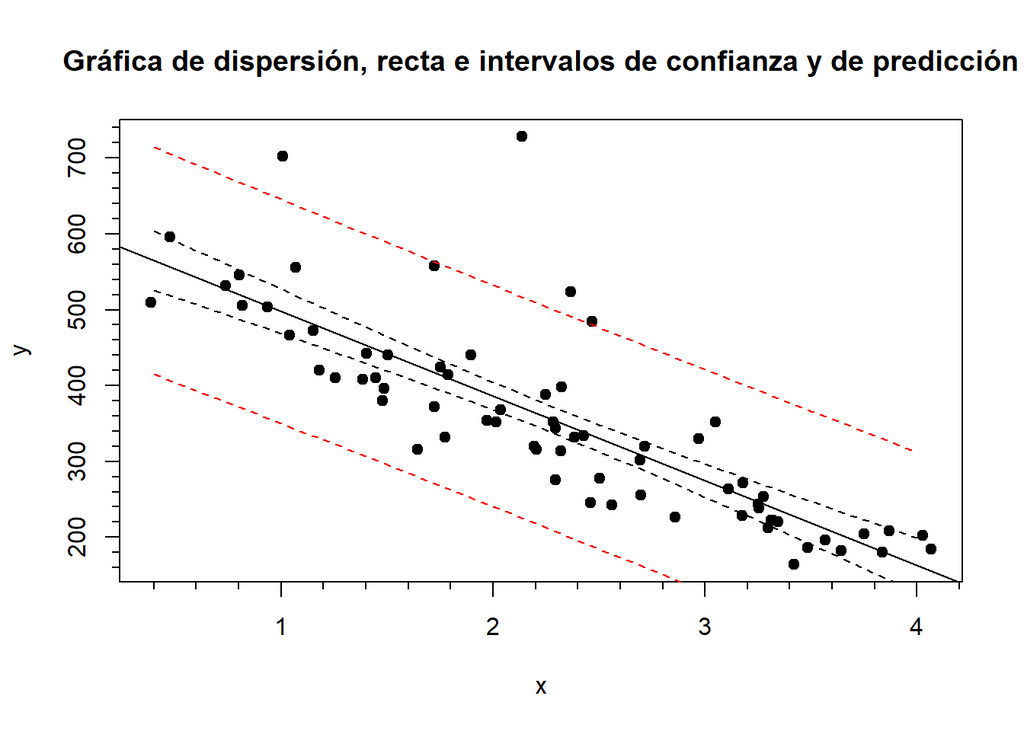

## Ejemplo 25

Se desea relacionar el caudal T ($m^{3}$/s) vs concentración de un contaminante V (STD, ppm) en una corriente de agua. Los datos se muestran a continuación.

Analizar mediante regresión lineal simple.

| T | V |
| --- | --- |
| 24.9 | 1.1330 |
| 35.0 | 0.9772 |
| 44.9 | 0.8532 |
| 55.1 | 0.7550 |
| 65.2 | 0.6723 |
| 75.2 | 0.6021 |
| 85.2 | 0.5420 |
| 95.2 | 0.5074 |

Las gráficas de los datos y sus transformación a través de logaritmo natural.

[figure not shown]

**Modelo 1**: Regresión con los datos originales:

```
##
## Call:
## lm(formula = y ~ x)
##
## Residuals:
##       Min        1Q    Median        3Q       Max
## -0.043955 -0.035863 -0.009305  0.019900  0.069559
##
## Coefficients:
##               Estimate Std. Error t value Pr(>|t|)
## (Intercept)  1.2815107  0.0468683   27.34 1.58e-07 ***
## x           -0.0087578  0.0007284  -12.02 2.01e-05 ***
## ---
## Signif. codes:  0 '***' 0.001 '**' 0.01 '*' 0.05 '.' 0.1 ' ' 1
##
## Residual standard error: 0.04743 on 6 degrees of freedom
## Multiple R-squared:  0.9602, Adjusted R-squared:  0.9535
## F-statistic: 144.6 on 1 and 6 DF,  p-value: 2.007e-05
```

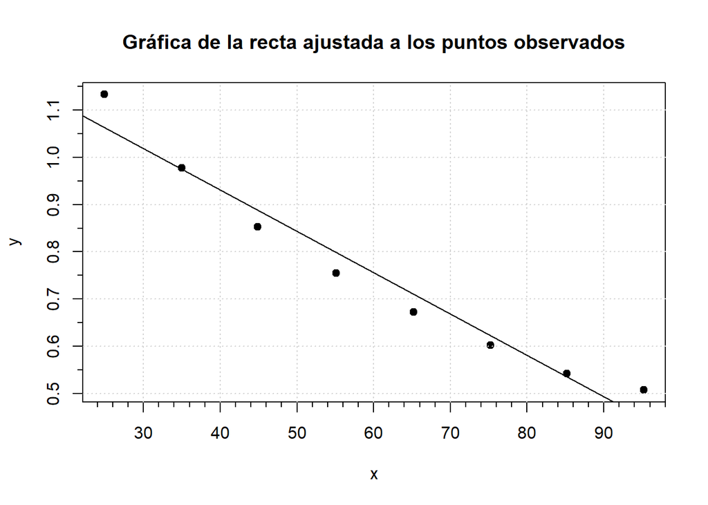

**Pruebas de linealidad (normalidad de los residuos):**

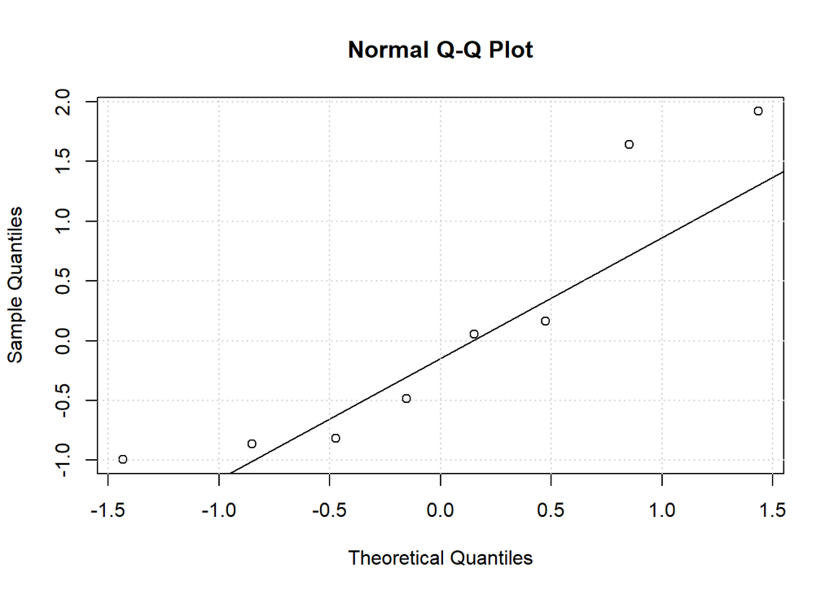

```
##
##  Shapiro-Wilk normality test
##
## data:  residuos
## W = 0.84494, p-value = 0.08462
```

```
##
##  Anderson-Darling normality test
##
## data:  residuos
## A = 0.55369, p-value = 0.1036
```

```
##
##  Lilliefors (Kolmogorov-Smirnov) normality test
##
## data:  residuos
## D = 0.21963, p-value = 0.307
```

Cumple con las pruebas de normalidad.

**Prueba de heterocedasticidad:**

```
##
##  studentized Breusch-Pagan test
##
## data:  modelo_1
## BP = 0.31196, df = 1, p-value = 0.5765
```

Cumple la prueba de heterocedasticidad.

**Prueba de independencia:**

```
##
##  Durbin-Watson test
##
## data:  modelo_1
## DW = 0.73351, p-value = 0.000695
## alternative hypothesis: true autocorrelation is greater than 0
```

No cumple al prueba de independencia.

En la gráfica siguiente se aprecia que se sigue un cierto patrón en forma de U.

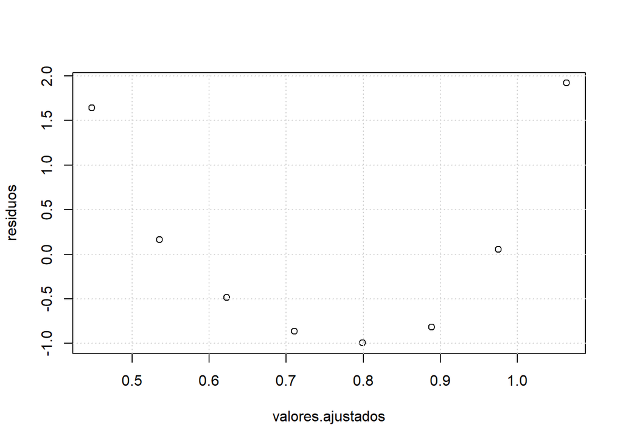

**Modelo 2**: Regresión con transformando *x = ln(x)*:

Regresión lineal:

```
##
## Call:
## lm(formula = y ~ x)
##
## Residuals:
##        Min         1Q     Median         3Q        Max
## -0.0062609 -0.0039317 -0.0009493  0.0012340  0.0119894
##
## Coefficients:
##             Estimate Std. Error t value Pr(>|t|)
## (Intercept)  2.66506    0.02154  123.72 1.88e-11 ***
## x           -0.47622    0.00534  -89.17 1.34e-10 ***
## ---
## Signif. codes:  0 '***' 0.001 '**' 0.01 '*' 0.05 '.' 0.1 ' ' 1
##
## Residual standard error: 0.006525 on 6 degrees of freedom
## Multiple R-squared:  0.9992, Adjusted R-squared:  0.9991
## F-statistic:  7952 on 1 and 6 DF,  p-value: 1.34e-10
```

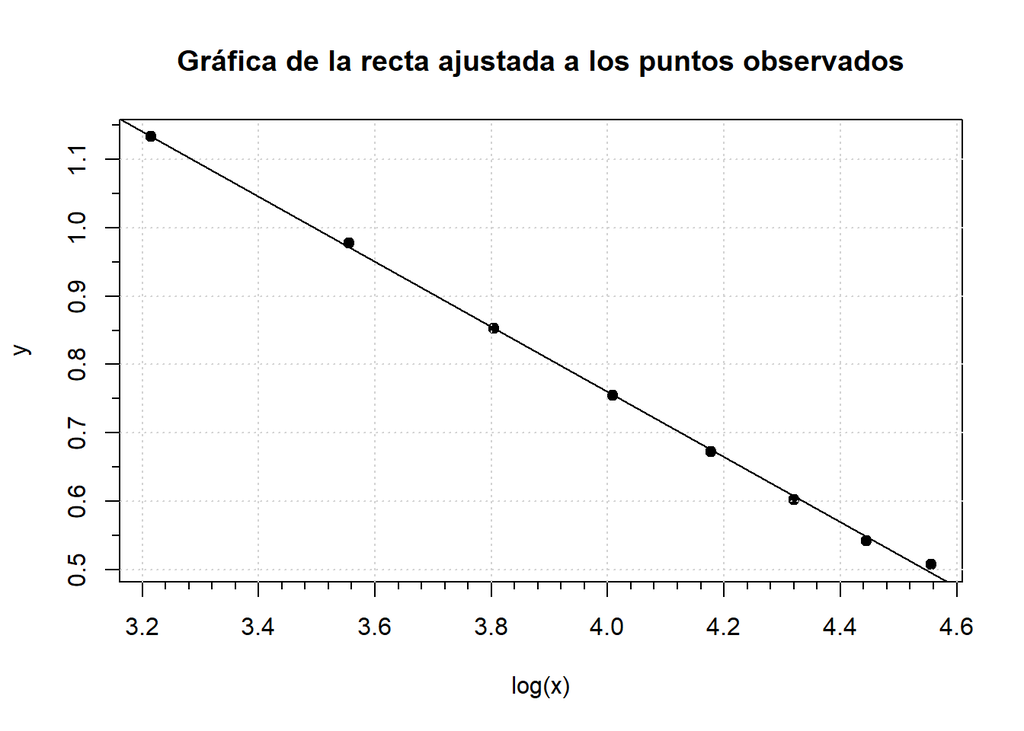

**Prueba de linealidad:**

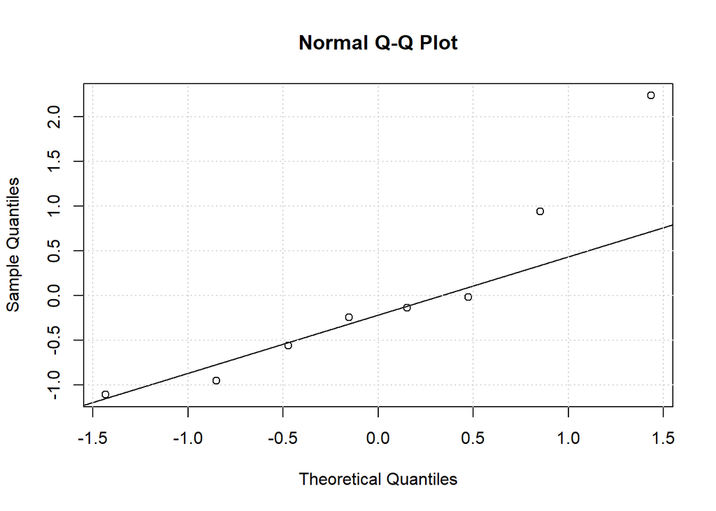

```
##
##  Shapiro-Wilk normality test
##
## data:  residuos
## W = 0.88216, p-value = 0.1975
```

```
##
##  Anderson-Darling normality test
##
## data:  residuos
## A = 0.44845, p-value = 0.2014
```

```
##
##  Lilliefors (Kolmogorov-Smirnov) normality test
##
## data:  residuos
## D = 0.26372, p-value = 0.1039
```

Cumple con normalidad.

**Prueba de heterocedasticidad:**

```
##
##  studentized Breusch-Pagan test
##
## data:  modelo_2
## BP = 2.9461, df = 1, p-value = 0.08609
```

Cumple con heterocedasticidad.

**Prueba de independencia:**

```
##
##  Durbin-Watson test
##
## data:  modelo_2
## DW = 1.6234, p-value = 0.1353
## alternative hypothesis: true autocorrelation is greater than 0
```

Cumple con independencia.

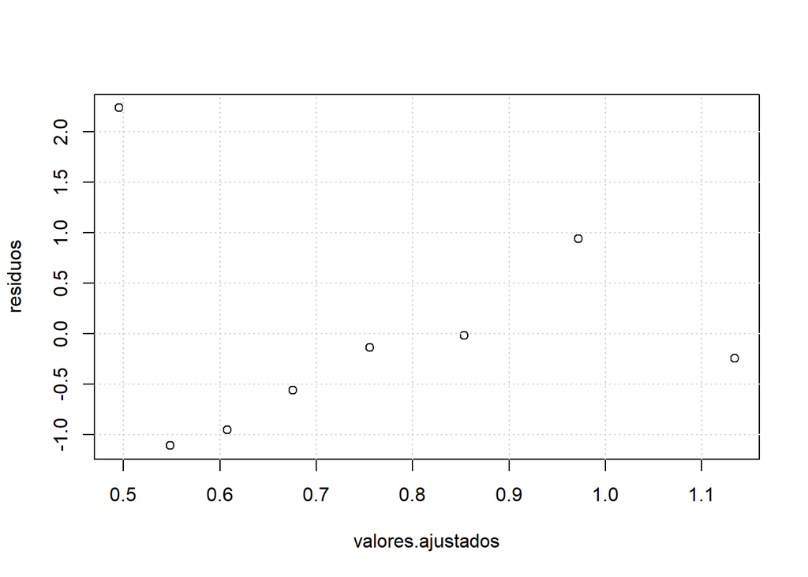

Como conclusión, la regresión lineal a través del modelo 2, puede aplicarse para obtener lo siguiente:

- Predecir *y* dado *x*
- Predecir *y* y una varianza para la predicción
- Obtener el mejor estimador lineal insesgado de *y*
- Probar hipótesis, estimar intervalos de confianza o de predicción